# HW7

Cheng Huang 2658312

26 October 2018

# Normal Mixture revisite

## Find posterior density

The likelihood function given $\delta, \mu_1, \mu_2, \sigma_1, \sigma_2$ is
$$f(x|\delta, \mu_1, \mu_2, \sigma_1, \sigma_2) = \prod_{i=1}^{n}[\delta \frac{1}{\sqrt{2\pi}\sigma_1}e^{-\frac{(x_i-\mu_1)^2}{2\sigma_1^2}}+(1-\delta) \frac{1}{\sqrt{2\pi}\sigma_2}e^{-\frac{(x_i-\mu_2)^2}{2\sigma_2^2}}]$$
The prior for $\mu_1, \mu_2$ are normal $N(0, 10^2)$, so
$$\pi(\mu_1) \propto exp(-\frac{\mu_1^2}{200})$$
$$\pi(\mu_2) \propto exp(-\frac{\mu_2^2}{200})$$
The prior for $\sigma_1^2, \sigma_2^2$ are $IG(0.5, 10)$, so
$$\pi(\sigma_1^2) \propto (\sigma_1^2)^{-1.5}exp(-\frac{10}{\sigma_1^2})$$
$$\pi(\sigma_2^2) \propto (\sigma_2^2)^{-1.5}exp(-\frac{10}{\sigma_2^2})$$
Therefore the posterior distribution propotional to
$$q(\delta, \mu_1, \mu_2, \sigma_1, \sigma_2|x) \propto \prod_{i=1}^{n}[\delta \frac{1}{\sqrt{2\pi}\sigma_1}e^{-\frac{(x_i-\mu_1)^2}{2\sigma_1^2}}+(1-\delta) \frac{1}{\sqrt{2\pi}\sigma_2}e^{-\frac{(x_i-\mu_2)^2}{2\sigma_2^2}}] \times exp(-\frac{\mu_1^2}{200}) \times exp(-\frac{\mu_2^2}{200})$$
$$\times (\sigma_1^2)^{-1.5}exp(-\frac{10}{\sigma_1^2}) \times (\sigma_2^2)^{-1.5}exp(-\frac{10}{\sigma_2^2})$$

## MCMC

```r
library("invgamma")
library("HI")
n <- 100
## set true value of parameters
delta <- 0.7
mu1 <- 7
mu2 <- 10
sigmasq1 <- 0.5
sigmasq2 <- 0.5

## simulation
set.seed(123)
u <- rbinom(n, prob = delta, size = 1)
x <- rnorm(n, ifelse(u == 1, mu1, mu2), ifelse(u == 1, sigmasq1, sigmasq2))

## calculate the posterior distribution
logposterior <- function(delta, mu1, mu2, sigmasq1, sigmasq2, x = x) {
  logL <- sum(log(delta * dnorm(x, mu1, sqrt(sigmasq1))+(1-delta)*dnorm(x, mu2, sqrt(sigmasq2))))
  logprior.mu1 <- dnorm(mu1, 0, 10, log = T)
  logprior.mu2 <- dnorm(mu2, 0, 10, log = T)
  logprior.sigma1 <- dinvgamma(sigmasq1, 0.5, 10, log = T)
  logprior.sigma2 <- dinvgamma(sigmasq2, 0.5, 10, log = T)

  return(logL + logprior.mu1 + logprior.mu2 + logprior.sigma1 + logprior.sigma2)
}

mymcmc <- function (){

}
```

[output not shown]

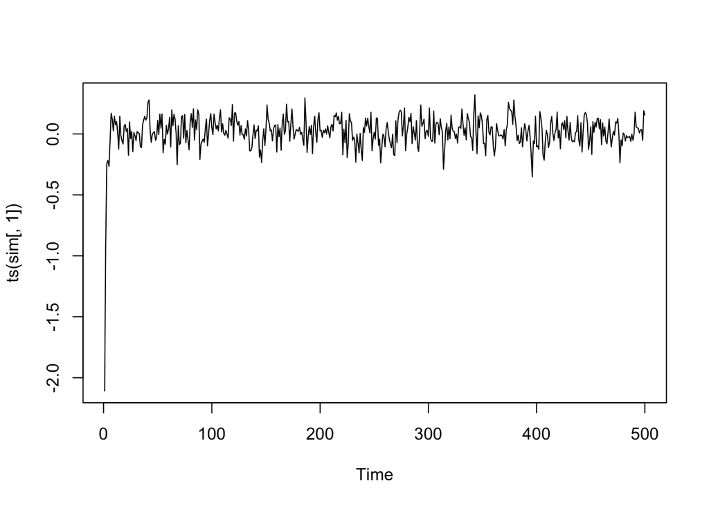

```r
n <- 100
a <- 0.0; b <- 0.5
x <- rnorm(n)
y <- rpois(n, exp(a + b * x))
mydata <- data.frame(y = y, x = x)

logpost <- function(theta, data, sigma2, tau2) {
  a <- theta[1]; b <- theta[2]
  x <- data$x; y <- data$y
  return(a * sum(y) + b * sum(x * y) - exp(a) * sum(exp(b * x))
         - a^2 / 2 / sigma2 - b^2 / 2 / tau2)
}

mymcmc <- function(niter, thetaInit, data, sigma2, tau2) {
  p <- length(thetaInit)
  thetaCurrent <- thetaInit
  out <- matrix(NA, niter, p)
  for (i in 1:niter) {
    for (j in 1:p) {
      logFC <- function(thj) {
        theta <- thetaCurrent
        theta[j] <- thj
        logpost(theta, data, sigma2, tau2)
      }
      ## arms algorithm
      out[i, j] <- thetaCurrent[j] <-
        HI::arms(thetaCurrent[j], logFC,
                 function(x) ((x > -10) * (x < 10)), 1)
    }
  }
  out
}

niter <- 500
thetaInit <- c(2, 2)
sigma2 <- tau2 <- 100
sim <- mymcmc(niter, thetaInit, mydata, sigma2, tau2)
plot(ts(sim[,1]))
```

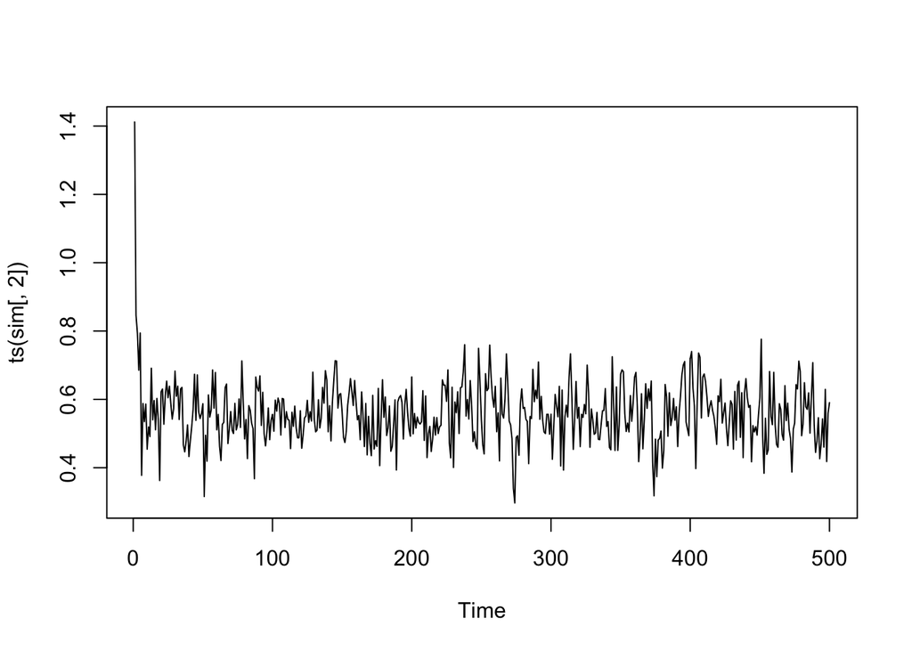

```r
plot(ts(sim[,2]))
```

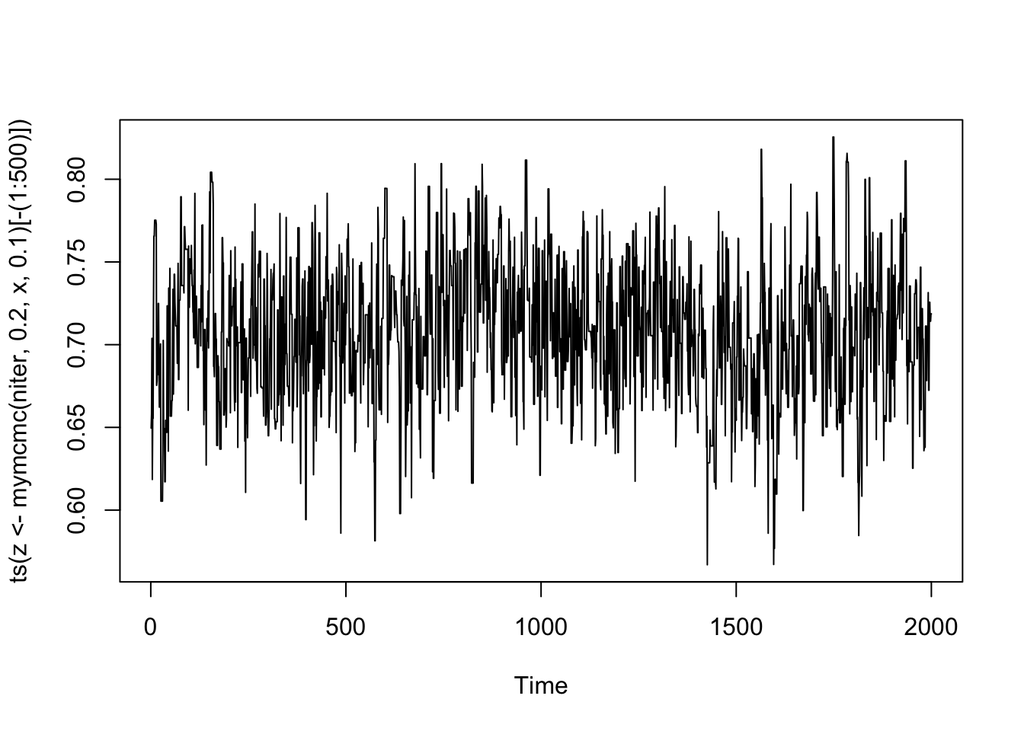

```r
delta <- 0.7 # true value to be estimated based on the data
n <- 100
set.seed(123)
u <- rbinom(n, prob = delta, size = 1)
x <- rnorm(n, ifelse(u == 1, 7, 10), 0.5)

mylike <- function(delta, x) {
    prod(delta * dnorm(x, 7, 0.5) + (1 - delta) * dnorm(x, 10, 0.5))
}

## simple random walk chain
myRange <- function(v, width) {
    min(1, v + width) - max(0, v - width)
}

mymcmc <- function(niter, init, x, width) {
    v <- double(niter)
    for (i in 1:niter) {
        cand <- runif(1, max(0, init - width), min(1, init + width))
        ratio <- mylike(cand, x) / myRange(cand, width) /
            mylike(init, x) * myRange(init, width)
        if (runif(1) < min(ratio, 1)) {
            v[i] <- init <- cand
        } else v[i] <- init
    }
    v
}
niter <- 2500
plot(ts(z <- mymcmc(niter, .2, x, .1)[-(1:500)]))
```

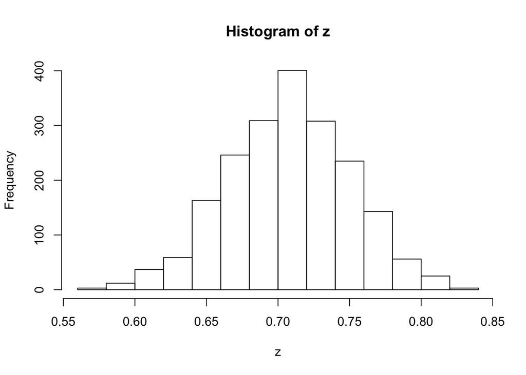

```r
hist(z)
```

# Mixture Proposal

## Mixture of Beta

$f(x) \propto \frac{x^{\theta-1}}{1+x^2} + \sqrt{2 + x^2}(1-x)^{\beta-1} \le x^{\theta-1}+\sqrt{3}(1-x)^{\beta-1}$, therefore choose $g(x)=\lambda Beta(\theta,1) + (1-\lambda)Beta(1, \beta) = \lambda \theta x^{\theta-1}+(1-\lambda)\beta (1-x)^{\beta-1}$.
Choose $\lambda = 1/2$,
$$g(x) = \frac{\theta}{2} x^{\theta-1}+\frac{\beta}{2} (1-x)^{\beta-1}$$
Therefore,
$$f(x)\le x^{\theta-1}+\sqrt{3}(1-x)^{\beta-1} \le \alpha g(x) = \frac{M \theta}{2}x^{\theta-1} +\frac{M \beta}{2}(1-x)^{\beta-1}$$
This Inequality holds when $M = max(2/\theta,2\sqrt{3}/\beta)$.

Select $\theta = 2, \beta = 1, M = 2\sqrt{3}$. Then $Mg(x) = 2\sqrt{3}x+\sqrt{3}$,The sample is accepted when $U \le \frac{f(X)}{Mg(X)}=\frac{\frac{x}{1+x^2} + \sqrt{2 + x^2}}{2\sqrt{3}x+\sqrt{3}}$.  
Pseudo - code  
(1)draw U ~ U(0,1), X ~ g(x)  
(2)if $U \le \frac{f(x)}{Mg(x)}$, return X else go back to (1)  
(3)return X

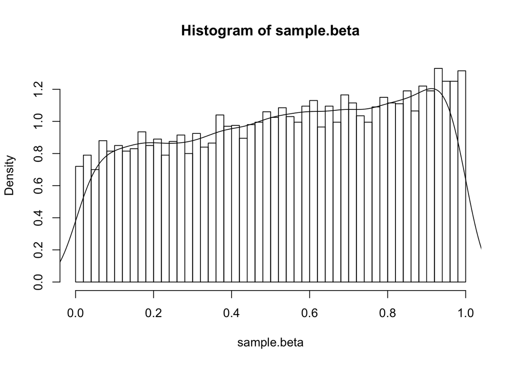

```r
knitr::opts_chunk$set(echo = TRUE)
require(data.table)
sample.beta <- function(n){
  u <- runif(n)
  g1 <- rbeta(n, shape1 = 2, shape2 = 1)
  g2 <- rbeta(n, shape1 = 1, shape2 = 1)
  weight1 <- 1/2
  weight2 <- 1 - weight1
  if(u < weight1){
    return(g1[u < weight1])
  }else{
    return(g2[u >= weight1])
  }
}
rejection.beta <- function(n, theta){
  iter <- 1
  sample <- rep(0,n)
  while (iter <= n) {
    u <- runif(1)
    x <- sample.beta(1)
    if(u <= (x/(1 + x^2) + sqrt(2 + x^2))/(2 * sqrt(3) * x + sqrt(3))){
      sample[iter] <- x
      iter <- iter +1
    }
  }
  sample
}
sample.beta <- rejection.beta(10000)


hist(sample.beta, prob = TRUE, breaks = 50)
lines(density(sample.beta))
```

## Dealing with two components using Beta

It is shown from above that for $x \in [0,1]$
$$f_1(x) = \frac{x^{\theta-1}}{1+x^2} \le x^{\theta-1}$$
So define $g_1(x)=\theta x^{\theta-1}$, such that
$$f_1(x)= \frac{x^{\theta-1}}{1+x^2} \le x^{\theta-1}\le M_1g_1(x)=M_1\theta x^{\theta-1}$$
So, the minimal of $M_1$ is $1/\theta$. So Criterion for accepting a sample is $U \le \frac{f_1(x)}{M_1g_1(x)}=\frac{1}{1+x^2}$
For the second component,
$$f_2(x) = \sqrt{2 + x^2}(1-x)^{\beta-1} \le \sqrt{3}(1-x)^{\beta-1}$$
So define $g_2(x)=\beta (1-x)^{\beta-1}$, such that
$$f_2(x)= \sqrt{2 + x^2}(1-x)^{\beta-1} \le \sqrt{3}(1-x)^{\beta-1}\le M_2g_2(x)=M_2\beta (1-x)^{\beta-1}$$
So, the minimal of $M_1$ is $\sqrt{3}/\beta$. So Criterion for accepting a sample is $U \le \frac{f_2(x)}{M_2g_2(x)}=\sqrt{\frac{2+x^2}{3}}$

Pseudo - code  
(1)draw $U \sim U(0,1)$  
(2)if $U \le \frac{M_1}{M_1+M_2}$, draw $U_1 \sim U(0,1), X_1 \sim g_1(x)$  
(3)if $U_1 \le \frac{f_1(x)}{M_1g_1(x)}$, return $X_1$ else go back to (2)  
(4)if $U > \frac{M_1}{M_1+M_2}$, draw $U_2 \sim U(0,1), X_2 \sim g_2(x)$  
(5)if $U_2 \le \frac{f_2(x)}{M_2g_2(x)}$, return $X_2$ else go back to (4)

Select $\theta = 2, \beta = 1$.

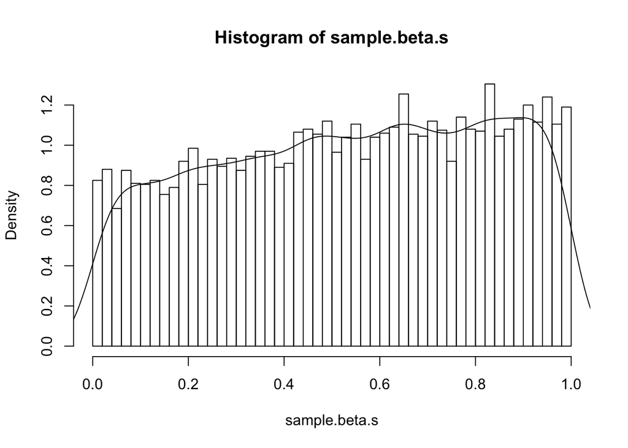

```r
knitr::opts_chunk$set(echo = TRUE)
require(data.table)
sample.beta.s <- function(n){
  iter <- 1
  sample <- rep(0,n)
  u <- runif(n)
  M1 <- 1/2
  M2 <- sqrt(3)
  weight1 <- M1/(M1 + M2)
  while (iter <= n) {
    if(u[iter] < weight1){
      u1 <- runif(1)
      g1 <- rbeta(1, shape1 = 2, shape2 = 1)
      if(u1 <= 1/(1+g1^2)){
        sample[iter] <- g1
        iter <- iter +1
       }
    }else{
      u2 <- runif(1)
      g2 <- rbeta(n, shape1 = 1, shape2 = 1)
      if(u2 <= sqrt((2+g2^2)/3)){
        sample[iter] <- g2
        iter <- iter +1
       }
    }
  }
  sample
}

sample.beta.s <- sample.beta.s(10000)
hist(sample.beta.s, prob = TRUE, breaks = 50)
lines(density(sample.beta.s))
```

# Reference

[jun-yan/stat-5361]https://github.com/jun-yan/stat-5361